# ChIP-seq workshop - Hands-on Roscoff 2025

Elodie Darbo; Stéphanie Le Gras; Pascal Martin;

2025 November 18-20

# 1 - Introduction

## 1.1 - Goal

The aim is to :

- understand the nature of ChIP-Seq data
- perform a complete analysis workflow including quality check (QC), read mapping, visualization in a genome browser and peak-calling. Use command line and open source software for each step of the workflow and feel the complexity of the task
- have an overview of some possible downstream analyses
- perform a motif analysis with online web programs

## 1.2 - Summary

This training gives an introduction to ChIP-seq data analysis, covering the processing steps starting from the reads to the peaks. Among all possible downstream analyses, the practical aspect will focus on motif analyses. A particular emphasis will be put on deciding which downstream analyses to perform depending on the biological question. This training does not cover all methods available today. It does not aim at bringing users to a professional NGS analyst level but provides enough information to allow biologists understand what is DNA sequencing in practice and to communicate with NGS experts for more in-depth needs.

## 1.3 - Dataset description

For this training, we will use two datasets:

- a dataset produced by Myers et al [Pubmed](http://www.ncbi.nlm.nih.gov/pubmed/23818864) involved in the regulation of gene expression under anaerobic conditions in bacteria. We will focus on one factor: **FNR**. The advantage of this dataset is its small size, allowing real time execution of all steps of the dataset
- a dataset of ChIP-seq peaks obtained in different mouse tissues for the p300 co-activator protein by Visel et al. [Pubmed](https://www.ncbi.nlm.nih.gov/pmc/articles/PMC2745234/); we will use this dataset to illustrate downstream annotation of peaks using R.

# 2 - Downloading ChIP-seq reads from NCBI

**Goal**: Identify the datasets corresponding to the studied article and retrieve the data (reads as FASTQ files) corresponding to 2 replicates of a condition and the corresponding control.

## 2.1 - Obtaining an identifier for a chosen dataset

NGS datasets are (usually) made freely accessible for other scientists, by depositing these datasets into specialized databanks. [Sequence Read Archive (SRA)](http://www.ncbi.nlm.nih.gov/sra) located in USA hosted by NCBI, and its European equivalent [European Nucleotide Archive (ENA)](http://www.ebi.ac.uk/ena) located in England hosted by EBI both contains **raw reads**.

Functional genomic datasets (transcriptomics, genome-wide binding such as ChIP-seq,…) are deposited in the databases [Gene Expression Omnibus (GEO)](http://www.ncbi.nlm.nih.gov/geo/) or its European equivalent [ArrayExpress](https://www.ebi.ac.uk/arrayexpress/).

Within an article of interest, search for a sentence mentioning the deposition of the data in a database. Here, the following sentence can be found at the end of the Materials and Methods section: *“All genome-wide data from this publication have been deposited in NCBI’s Gene Expression Omnibus (**GSE41195**).”* We will thus use the **GSE41195** identifier to retrieve the dataset from the **NCBI GEO** (Gene Expression Omnibus) database.

## 2.2 - Accessing GSE41195 from GEO

1. The GEO database hosts processed data files and many details related to the experiments. SRA (Sequence Read Archive) stores the actual raw sequence data.
2. Search in Google **GSE41195**. Click on the first link to directly access the correct page on the GEO database.

[figure not shown]

3. This GEO entry is a mixture of expression analysis (Nimblegen Gene Expression Array), chip-chip and chip-seq. At the bottom of the page, click on the subseries related to the chip-seq datasets. (this subseries has its own identifier: **GSE41187**).

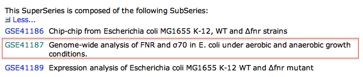

4. From this page, we will focus on the experiment **FNR IP ChIP-seq Anaerobic A**. At the bottom of the page, click on the link “**GSM1010219** - FNR IP ChIP-seq Anaerobic A”.
5. In the new page, go to the bottom to find the SRA identifier. This is the identifier of the raw dataset stored in the SRA database.

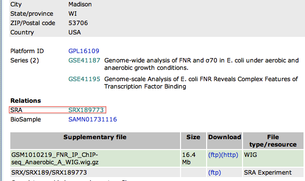

6. Click on the identifier **SRX189773**

## 2.3 - Downloading FASTQ file from the SRA database

SRA stores sequences in a FASTQ format.

1. Click on **SRR576933** in SRA
2. There are statistics on the run that generated the data.
3. Click on FASTA/FASTQ download. On the next page, there is a link to the FASTQ file. For efficiency, this file has already been downloaded.

**tip**: To download the replicate and control datasets, we should redo the same steps starting from the GEO web page specific to the chip-seq datasets (see step 2.4) and choose **FNR IP ChIP-seq Anaerobic B** and **anaerobic INPUT DNA**. Downloaded FASTQ files are available in the data folder (SRR576934.fastq.gz and SRR576938.fastq.gz respectively)

**Samples have been renamed to have explicite names**: * FNR_IP_ChIP-seq_Anaerobic_A.fastq.gz (SRR576933) * FNR_IP_ChIP-seq_Anaerobic_B.fastq.gz (SRR576934) * Anaerobic_INPUT_DNA.fastq.gz (SRR576938)

# 3 - Connect to the server and set up your environment

During this training, we will work on the cluster provided by the Institut Français de Bioinformatique (IFB) using JupyterLab through the ondemand system.

1. Go to [ondemand](https://ondemand.cluster.france-bioinformatique.fr/)
2. Select JupyterLab: Core

[figure not shown]

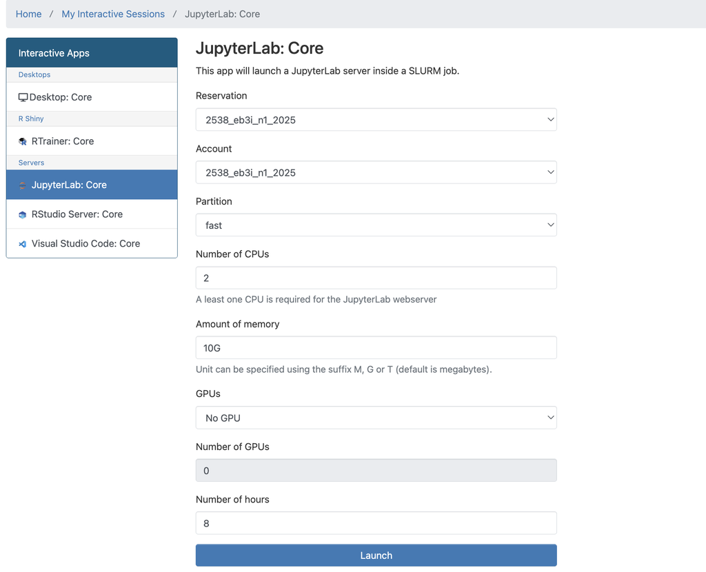

4. Once the job is running, click on Connect to Jupyter

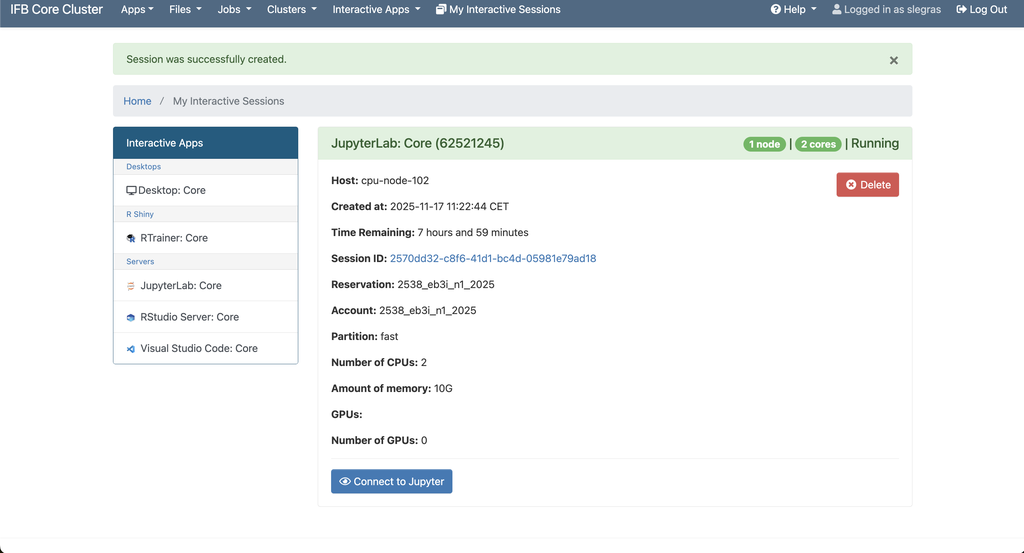

## 3.1 - Set up your working environment

1. Go to your project directory

```bash
cd /shared/projects/<your_project>
```

2. Create a directory that will contain all results of the upcoming analyses.

```bash
mkdir EBAII2025_chipseq
```

3. Go to the newly created directory

```bash
cd EBAII2025_chipseq
```

4. Copy the directory containing data

```bash
cp -r /shared/projects/2538_eb3i_n1_2025/atelier_chipseq/training_data/data .
```

7. Your directory structure should be like this

```
/shared/projects/<your_project>/EBAII2025_chipseq
│
└───data
```

If you wish, you can check your directory structure:

```bash
 tree
```

# 4 - Quality control of the reads and statistics

**Goal**: Get some basic information on the data (read length, number of reads, global quality of datasets)

## 4.1 - Generating the FASTQC report

Before you analyze the data, it is crucial to check the quality of the data. We will use the standard tool for checking the quality of data generated on the Illumina platform: [FASTQC](http://www.bioinformatics.babraham.ac.uk/projects/fastqc/).

1. Create a directory named **01-QualityControl** in which to output results from fastqc

```bash
mkdir 01-QualityControl
```

2. Go to the directory you’ve just created

```bash
cd 01-QualityControl
```

Your directory structure should be like this

```
/shared/projects/<your_project>/EBAII2025_chipseq
│
└───data
│
└───01-QualityControl <- you should be in this folder
```

3. Get FastQC available in your environment

```bash
module load fastqc/0.11.9
```

4. Check the help page of the program to see its usage and parameters.

```bash
fastqc --help
```

5. Launch the FASTQC program on the experiment file (FNR_IP_ChIP-seq_Anaerobic_A.fastq.gz)
- -o: creates all output files in the specified output directory. ‘.’ means current directory.

```bash
fastqc ../data/FNR_IP_ChIP-seq_Anaerobic_A.fastq.gz -o .
```

6. Wait until the analysis is finished. Check the FastQC result files.

```bash
ls
```

> FNR_IP_ChIP-seq_Anaerobic_A_fastqc.html FNR_IP_ChIP-seq_Anaerobic_A_fastqc.zip
7. Go to the directory /shared/projects/<your_project>/EBAII2025_chipseq/1-QualityControl in the tree directory on the left of the jupyterhub window and double click on FNR_IP_ChIP-seq_Anaerobic_A_fastqc.html to visualize the file.

[figure not shown]

8. Launch the FASTQC program on the replicate (FNR_IP_ChIP-seq_Anaerobic_B.fastq.gz) and on the control file (Anaerobic_INPUT_DNA.fastq.gz)

**Analyze the result of the FASTQC program:**

- **How many reads are present in each file ?**
- **What is the read length ?**
- **Is the overall quality good for the three samples ?**
- **Are there any concerns raised by the report ? If so, can you tell where the problem might come from ?**
10. Once you are done with FastQC, unload it

```bash
module unload fastqc/0.11.9
```

# 5 - Mapping the reads with Bowtie

**Goal**: Obtain the coordinates of each read to the reference genome.

## 5.1 - Choosing a mapping program

There are multiple programs to perform the mapping step. For reads produced by an Illumina machine for ChIP-seq, the currently “standard” programs is Bowtie (versions 1 and 2)(Langmead et al. 2009) (Langmead and Salzberg 2012). We will use **Bowtie version 2.5.1** for this exercise.

## 5.2 - Bowtie

1. Load Bowtie

```bash
module load bowtie2/2.5.1
```

2. Try out bowtie

```bash
bowtie2
```

This prints the help of the program. However, this is a bit difficult to read ! If you need to know more about the program, it’s easier to directly check out the manual on the [website](https://bowtie-bio.sourceforge.net/bowtie2/manual.shtml).

3. Bowtie needs the reference genome to align each read on it. The genome needs to be in a specific format (=index) for bowtie to be able to use it. Several pre-built indexes are available for download on bowtie webpage, but our genome is not there. You will need to make this index file.
4. Create a directory named **02-Mapping** in which to output mapping results

```bash
cd ..
mkdir 02-Mapping
```

5. Go to the directory you’ve just created

```bash
cd 02-Mapping
```

## 5.3 - Prepare the index file

1. To make the index file, you will need the complete genome, in FASTA format. It has already been downloaded to gain time (Escherichia_coli_K12.fasta in the course folder) (The genome was downloaded from the NCBI).
2. Create a directory named **index** in which to output bowtie indexes

```bash
mkdir index
```

3. Go to the newly created directory

```bash
cd index
```

4. Try out bowtie2-build

```bash
bowtie2-build
```

5. Build the index for bowtie

```bash
## Creating genome index : provide the path to the genome file and the name to give to the index (Escherichia_coli_K12)
bowtie2-build ../../data/Escherichia_coli_K12.fasta Escherichia_coli_K12
```

6. Go back to upper directory i.e 02-Mapping

```bash
cd ..
```

## 5.4 - Mapping the samples

1. Create a directory named **bam** to put mapping results

```bash
mkdir bam
```

2. Go to the newly created directory bam

```bash
cd bam
```

Your directory structure should be like this:

```
/shared/projects/<your_project>/EBAII2025_chipseq
│
└───data
│
└───01-QualityControl
│
└───02-Mapping
|    └───index
|    └───bam <- you should be here
```

3. Let’s see the parameters of bowtie before launching the mapping:
- -x to specify genome index prefix
- -U to specify file with reads to be mapped
- -3 will trim x base from the end of the read. As our last position is of low quality, we’ll trim 1 base.
- -S will output the result in SAM format
- –mm allows many concurrent bowtie processes on the same computer to share the same memory image of the index
- 2> FNR_IP_ChIP-seq_Anaerobic_A.out will output some statistics about the mapping in the file FNR_IP_ChIP-seq_Anaerobic_A.out

```bash
## Run alignment
## Tip: first type bowtie command line then add quotes around and prefix it with "sbatch --cpus 10 --wrap="

sbatch -p fast -o FNR_IP_ChIP-seq_Anaerobic_A.mapping.out --cpus-per-task 10 --wrap="bowtie2 -p 10 --mm -3 1 -x ../index/Escherichia_coli_K12 -U ../../data/FNR_IP_ChIP-seq_Anaerobic_A.fastq.gz -S FNR_IP_ChIP-seq_Anaerobic_A.sam"
```

This should take few minutes as we work with a small genome. For the human genome, we would need either more time and more resources.

Analyze the result of the mapped reads:  
Open the file FNR_IP_ChIP-seq_Anaerobic_A.mapping.out (for example using the `less` command), which contains some statistics about the mapping. How many reads were mapped? How many multi-mapped reads were originally present in the sample? To quit less press ‘q’

Bowtie output is a [SAM](https://samtools.github.io/hts-specs/SAMv1.pdf) file. The SAM format corresponds to large text files, that can be compressed (“zipped”) into a BAM format. The BAM files takes up to 4 time less disk space and are usually sorted and indexed for fast access to the data it contains. The index of a given .bam file is named .bam.bai or .bai file. Some tools require to have the index of the bam file to process it.

4. multimapped reads are given a very low mapping quality (below 10). Remove reads which mapping quality is below 10, sort the sam file and create a bam file using samtools (Li et al. 2009). samtools view is used to filter data based on mapping quality and samtools sort is used to sort data based on genomic coordinates.
- -@: number of processors to use
- -q: to set a threshold to the mapping quality
- -b: to output a BAM file (it is a SAM file by default)
- -o: to specify a output file name

```bash
## First load samtools
module load samtools/1.18
## Then run samtools
samtools view -@ 2 -q 10 -b FNR_IP_ChIP-seq_Anaerobic_A.sam | samtools sort -@ 2 - -o FNR_IP_ChIP-seq_Anaerobic_A.bam
```

5. Create an index for the bam file

```bash
samtools index FNR_IP_ChIP-seq_Anaerobic_A.bam
```

6. Compress the .sam file (you could also delete the file)

```bash
gzip FNR_IP_ChIP-seq_Anaerobic_A.sam
```

7. Once it’s done, unload the tools you used

```bash
module unload samtools/1.18 bowtie2/2.5.1
```

## 5.5 - Map the second replicate and the control

1. Repeat the steps above (3 -> 6 - Mapping) for the files FNR_IP_ChIP-seq_Anaerobic_B.fastq.gz and Anaerobic_INPUT_DNA.fastq.gz in the directory named “**bam**” within the directory 02-Mapping.

Analyze the result of the mapped reads:  
How many reads were mapped for samples Anaerobic_INPUT_DNA and FNR_IP_ChIP-seq_Anaerobic_B?

# 6 - Estimating the number of duplicated reads

**Goal**: Duplicated reads i.e reads mapped at the same positions in the genome are present in ChIP-seq results. They can arise from several reasons including a biased amplification during the PCR step of the library prep, DNA fragments coming from repetitive elements of the genome, sequencing saturation or the same clusters read several times on the flowcell (i.e optical duplicates). As analyzing ChIP-Seq data consist in detecting signal enrichment, we can not keep duplicated reads for subsequent analysis. So let’s detect them using [Picard](http://broadinstitute.github.io/picard/) (“Picard Tools - By Broad Institute” n.d.).

1. Go to the directory with alignment files

```bash
cd /shared/projects/<your_project>/EBAII2025_chipseq/02-Mapping/bam
```

2. Run Picard markDuplicates to mark duplicated reads (= reads mapping at the exact same location on the genome)
- CREATE_INDEX: Create .bai file for the result bam file with marked duplicate reads
- INPUT: input file name to mark for duplicate reads
- OUTPUT: output file name
- METRICS: file with duplicates marking statistics
- VALIDATION_STRINGENCY: Validation stringency for all SAM files read by picard.

```bash
## Load picard
module load picard/2.23.5

## Run picard
picard MarkDuplicates \
-CREATE_INDEX true \
-INPUT FNR_IP_ChIP-seq_Anaerobic_A.bam \
-OUTPUT Marked_FNR_IP_ChIP-seq_Anaerobic_A.bam \
-METRICS_FILE metric
```

To determine the number of duplicated reads marked by Picard, we can run the `samtools flagstat` command:

```bash
## Add samtools to your environment
module load samtools/1.18
## run samtools
samtools flagstat Marked_FNR_IP_ChIP-seq_Anaerobic_A.bam
```

**Run picard MarkDuplicates on the 2 other samples. How many duplicates are found in each sample?**

Go back to working home directory (i.e /shared/projects/<your_project>/EBAII2025_chipseq/)

```bash
## Unload picard and samtools
module unload samtools/1.18 picard/2.23.5
## If you are in 02-Mapping/bam
cd ../..
```

# 7 - ChIP quality controls

**Goal**: This exercise aims at plotting the **Lorenz curve** to assess the quality of the ChIP.

## 7.1 - Plot the Lorenz curve with Deeptools

1. Create a directory named **03-ChIPQualityControls** in which to put mapping results for IP

```bash
mkdir 03-ChIPQualityControls
```

2. Go to the newly created directory

```bash
cd 03-ChIPQualityControls
```

3. Run Deeptools [plotFingerprint](http://deeptools.readthedocs.io/en/latest/content/tools/plotFingerprint.html) (Ramírez et al. 2016) to draw the Lorenz curve
- -b: List of indexed BAM files
- -plot: File name of the output figure (extension can be either “png”, “eps”, “pdf” or “svg”)
- –numberOfSamples: how many regions are used to plot the graph
- -p: Number of processors to use (2 processors)

```bash
## Load deeptools in your environment
module load deeptools/3.5.4
## Run deeptools fingerprint
plotFingerprint \
  -p 2 \
  --numberOfSamples 10000 \
  -b ../02-Mapping/bam/FNR_IP_ChIP-seq_Anaerobic_A.bam \
     ../02-Mapping/bam/FNR_IP_ChIP-seq_Anaerobic_B.bam \
     ../02-Mapping/bam/Anaerobic_INPUT_DNA.bam \
  -plot fingerprint_10000.png
```

4. If plotFingerprint takes to much time to run. Take the file that has already been prepared for the training.

```bash
cp /shared/projects/2538_eb3i_n1_2025/atelier_chipseq/EBAII2025_chipseq/03-ChIPQualityControls/fingerprint_10000.png .
```

5. Go find the file using the directory tree on the left of the Jupyterlab panel and click on the fingerprint_10000.png file to display it in Jupyterlab.

**Look at the result files fingerprint.png (add the plot to this report). Give an explanation of the curves?**

Go back to working home directory (i.e /shared/projects/<your_project>/EBAII2025_chipseq)

```bash
## Unload deepTools
module unload deeptools/3.5.4
## If you are in 03-ChIPQualityControls
cd ..
```

# 8 - Visualizing the data in a genome browser

**Goal**: Check whether the IP worked: visualize the data in their genomic context.

## 8.1 - Choosing a genome browser

There are several options for genome browsers, divided between the local browsers (which you need to install on your computer, eg. IGV) and the online genome browsers (eg. UCSC genome browser, Ensembl). We often use both types, depending on the aim and the localization of the data. If the data are on your computer, to prevent data transfer, it’s easier to visualize the data locally (IGV). Note that if you’re working on a non-model organism, the local viewer will be the only choice. If the aim is to share the results with your collaborators, view many tracks in the context of many existing annotations, then the online genome browsers are more suitable.

## 8.2 - Viewing the raw alignment data in IGV

1. Download the following files from the server onto your computer
- data/Escherichia_coli_K12.fasta
- data/Escherichia_coli_K_12_MG1655.annotation.fixed.gtf
- 02-Mapping/bam/FNR_IP_ChIP-seq_Anaerobic_A.bam
- 02-Mapping/bam/FNR_IP_ChIP-seq_Anaerobic_A.bam.bai
- 02-Mapping/bam/FNR_IP_ChIP-seq_Anaerobic_B.bam
- 02-Mapping/bam/FNR_IP_ChIP-seq_Anaerobic_B.bam.bai
- 02-Mapping/bam/Anaerobic_INPUT_DNA.bam
- 02-Mapping/bam/Anaerobic_INPUT_DNA.bam.bai
2. Open IGV on your computer
3. Load the genome
- Genomes / Load Genome from File…
- Select the fasta file Escherichia_coli_K12.fasta located into the data directory
4. Load an annotation file named Escherichia_coli_K_12_MG1655.annotation.fixed.gtf into IGV
- File / Load from File…
- Select the annotation file. The positions of the genes are now loaded.
5. Load the three bam files (FNR_IP_ChIP-seq_Anaerobic_A.bam, FNR_IP_ChIP-seq_Anaerobic_B.bam and Anaerobic_INPUT_DNA.bam) in IGV.
- File / Load from File…
- Select the bam files.

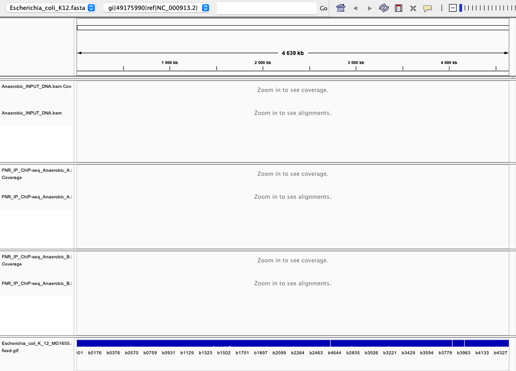

**Browse around in the genome. Specifically go to the following genes: pepT (geneID:b1127), ycfP (geneID:b1108). Do you see peaks (add screenshots to this report).**

However, looking at BAM file as such does not allow to directly compare the two samples as data are not normalized. Let’s generate normalized data for visualization.

## 8.3 - Viewing scaled data

[bamCoverage](https://deeptools.readthedocs.io/en/latest/content/tools/bamCoverage.html) from deepTools generates BigWigs out of BAM files 1. Try it out

```bash
## Load deeptools in your environment
module load deeptools/3.5.4
## run bamCoverage
bamCoverage --help
```

2. Create a directory named **04-Visualization** to store bamCoverage outputs

```bash
mkdir 04-Visualization
```

3. Go to the newly created directory

```bash
cd 04-Visualization
```

Your directory structure should be like this:

```
/shared/projects/<your_project>/EBAII2025_chipseq
│
└───data
│
└───01-QualityControl
│
└───02-Mapping
|    └───index
|    └───bam
│
└───03-ChIPQualityControls
│
└───04-Visualization <- you should be in this folder
```

```bash
bamCoverage \
  --bam ../02-Mapping/bam/Marked_FNR_IP_ChIP-seq_Anaerobic_A.bam \
  --outFileName FNR_IP_ChIP-seq_Anaerobic_A_nodup.bw \
  --outFileFormat bigwig \
  --effectiveGenomeSize 4639675 \
  --normalizeUsing CPM \
  --skipNonCoveredRegions \
  --extendReads 200 \
  --ignoreDuplicates
```

5. Do it for the replicate and the control.
6. Download the three bigwig files you have just generated
- 04-Visualization/FNR_IP_ChIP-seq_Anaerobic_A_nodup.bw
- 04-Visualization/FNR_IP_ChIP-seq_Anaerobic_B_nodup.bw
- 04-Visualization/Anaerobic_INPUT_DNA_nodup.bw
7. Load the three bigwig files in IGV
- File / Load from File…
- Select the three bigwig files.
8. Set the visualization of the three bigwig files to be autoscaled
- Click right on the name of the tracks and select **Autoscale**
- Click right on the name of the tracks and set the windowing function to Maximum

**Go back to the genes we looked at earlier: pepT, ycfP (add screenshots to this report). Look at the shape of the signal.**  
**Keep IGV opened.**

Go back to working home directory (i.e /shared/projects/<your_project>/EBAII2025_chipseq)

```bash
## If you are in 04-Visualization
cd ..
```

# 9 - Peak calling with MACS2

**Goal**: Detect the peaks which are regions with high densities of reads and that correspond to where the studied factor was bound

## 9.1 - Choosing a peak-calling program

There are multiple programs to perform the peak-calling step. Some are more directed towards histone marks (broad peaks) while others are specific to transcription factors which present narrow peaks. Here we will use the callpeak function of MACS2 (version 2.2.7.1) because it’s known to produce generally good results, and it is well-maintained by the developer.

## 9.2 - Calling the peaks

1. Create a directory named **05-PeakCalling** and one directory named **replicates** within to store peaks coordinates.

```bash
mkdir 05-PeakCalling
mkdir 05-PeakCalling/replicates
```

2. Go to the newly created directory replicates

```bash
cd 05-PeakCalling/replicates
```

3. Try out MACS2

```bash
## Load macs2 in your environment
module load macs2/2.2.7.1
macs2 callpeak --help
```

This prints the help of the program.

4. Let’s see the parameters of MACS before launching the mapping:
- ChIP-seq tag file (-t) is the name of our experiment (treatment) mapped read file FNR_IP_ChIP-seq_Anaerobic_A.bam
- ChIP-seq control file (-c) is the name of our input (control) mapped read file Anaerobic_INPUT_DNA.bam
- –format BAM indicates the input file are in BAM format. Other formats can be specified (SAM,BED…)
- –gsize Effective genome size: this is the size of the genome considered “usable” for peak calling. This value is given by the MACS developers on their website. It is smaller than the complete genome because many regions are excluded (telomeres, highly repeated regions…). The default value is for human (2700000000.0), so we need to change it. As the value for E. coli is not provided, we will take the complete genome size 4639675.
- –name provides a prefix for the output files. We set this to FNR_Anaerobic_A, but it could be any name.
- –bw The bandwidth is the size of the fragment extracted from the gel electrophoresis or expected from sonication. By default, this value is 300bp. Usually, this value is indicated in the Methods section of publications. In the studied publication, a sentence mentions “400bp fragments (FNR libraries)”. We thus set this value to 400.
- –fix-bimodal indicates that in the case where macs2 cannot find enough paired peaks between the plus strand and minus strand to build the shifting model, it can bypass this step and use a extension size of 200bp by default.
- -p 1e-2 indicates that we report the peaks if their associated p-value is lower than 1e-2. This is a relaxed threshold as we want to keep a high number of false positives in our peak set to later compute the IDR analysis.
- &> MACS.out will output the verbosity (=information) in the file MACS.out

```bash
macs2 callpeak \
  -t ../../02-Mapping/bam/FNR_IP_ChIP-seq_Anaerobic_A.bam \
  -c ../../02-Mapping/bam/Anaerobic_INPUT_DNA.bam \
  --format BAM \
  --gsize 4639675 \
  --name 'FNR_Anaerobic_A' \
  --bw 400 \
  --fix-bimodal \
  -p 1e-2 \
  &> repA_MACS.out
```

5. Run macs2 for replicate A and replicate B.
6. In a new directory called pool, run macs2 for the pooled replicates A and B by giving both bam files as input treatment files (-t).

```bash
# You should be in 05-PeakCalling
cd ..
mkdir pool
cd pool

# Run macs2 for pooled replicates
macs2 callpeak \
  -t ../../02-Mapping/bam/FNR_IP_ChIP-seq_Anaerobic_A.bam \
     ../../02-Mapping/bam/FNR_IP_ChIP-seq_Anaerobic_B.bam \
  -c ../../02-Mapping/bam/Anaerobic_INPUT_DNA.bam \
  --format BAM \
  --gsize 4639675 \
  --name 'FNR_Anaerobic_pool' \
  --bw 400 \
  --fix-bimodal \
  -p 1e-2 \
  &> pool_MACS.out
```

## 9.3 - Analyzing MACS results

**Look at the files that were created by MACS. Explain the content of the result files ?**  
**How many peaks were detected by MACS2 for each sample and in the pool of samples ?**

## 9.4 - Calling peaks in a replicate-aware method (IDR)

In order to take advantage of having biological replicates, we will create a combine set of peaks based on the reproducibility of each individual replicate peak calling. We will use the **Irreproducible Discovery Rate** (IDR) algorithm.

1. Create a new directory to store the peak coordinates resulting after idr analysis

```bash
## You should be 05-PeakCalling
cd ..
mkdir idr
cd idr
```

Your directory structure should be like this:

```
/shared/projects/<your_project>/EBAII2025_chipseq
│
└───data
│
└───01-QualityControl
│
└───02-Mapping
|    └───index
|    └───bam
│
└───03-ChIPQualityControls
│
└───04-Visualization
|
└───05-PeakCalling
|    └───replicates
|    └───pool
|    └───idr <- you should be in this folder
```

2. Load the module idr and have a look at its parameters

```bash
## Load idr in your environment
module load idr/2.0.4.2
idr --help
```

- –samples : peak files of each individual replicate
- –peak-list : the peak file of the pooled replicates, it will be used as a master peak set to compare with the regions from each replicates
- –input-file-type : format of the peak file, in our case it is narrowPeak
- –output-file : name of the result file
- –plot : plot additional diagnosis plot
3. Run idr

```bash
idr \
  --samples ../replicates/FNR_Anaerobic_A_peaks.narrowPeak \
            ../replicates/FNR_Anaerobic_B_peaks.narrowPeak \
  --peak-list ../pool/FNR_Anaerobic_pool_peaks.narrowPeak \
  --input-file-type narrowPeak \
  --output-file FNR_anaerobic_idr_peaks.bed \
  --plot
```

**Add the IDR graph to this report. How many peaks are found with the IDR method?**

4. Remove IDR and MACS2 from your environment and go back to working home directory (i.e /shared/projects/<your_project>/EBAII2025_chipseq)

```bash
module unload macs2/2.2.7.1
module unload idr/2.0.4.2

## If you are in 05-PeakCalling/idr
cd ../..
```

## 9.5 - Visualize peaks into IGV

1. Download the following BED files from the server into your computer to visualise in IGV :
- 05-PeakCalling/replicates/FNR_Anaerobic_A_peaks.narrowPeak
- 05-PeakCalling/replicates/FNR_Anaerobic_B_peaks.narrowPeak
- 05-PeakCalling/pool/FNR_Anaerobic_pool_peaks.narrowPeak
- 05-PeakCalling/idr/FNR_anaerobic_idr_peaks.bed

**Go back again to the genes we looked at earlier: pepT, ycfP. Do you see peaks ?** **Navigate throught the genome to find peaks detected in the replicates (peak calling per replicate) and not found/kept with the IDR method**

**From now on, peak set we keep is the IDR peak set.**

# 10 - Motif analysis

**Goal**: Define binding motif(s) for the ChIPed transcription factor and identify potential cofactors

## 10.1 - Retrieve the peak sequences corresponding to the peak coordinate file (BED)

For the motif analysis, you first need to extract the sequences corresponding to the peaks. There are several ways to do this (as usual…). If you work on a UCSC-supported organism, the easiest is to use RSAT fetch-sequences or Galaxy. Here, we will use Bedtools (Quinlan and Hall 2010), as we have the genome of interest on our computer (Escherichia_coli_K12.fasta). 1. Create a directory named **06-MotifAnalysis** to store data needed for motif analysis

```bash
mkdir 06-MotifAnalysis
```

2. Go to the newly created directory

```bash
cd 06-MotifAnalysis
```

Your directory structure should be like this:

```
/shared/projects/<your_project>/EBAII2025_chipseq
│
└───data
│
└───01-QualityControl
│
└───02-Mapping
|    └───index
|    └───bam
│
└───03-ChIPQualityControls
│
└───04-Visualization
│
└───05-PeakCalling
│
└───06-MotifAnalysis <- you should be in this folder
```

3. Extract peak sequence in fasta format

```bash
## First load samtools
module load samtools/1.18
## Create an index of the genome fasta file
samtools faidx ../data/Escherichia_coli_K12.fasta

## First load bedtools
module load bedtools/2.30.0
## Extract fasta sequence from genomic coordinate of peaks
bedtools getfasta \
  -fi ../data/Escherichia_coli_K12.fasta \
  -bed ../05-PeakCalling/idr/FNR_anaerobic_idr_peaks.bed \
  -fo FNR_anaerobic_idr_peaks.fa
```

4. Download the file FNR_anaerobic_idr_peaks.fa on your computer

## 10.2 - Motif discovery with RSAT

1. Open a connection to a Regulatory Sequence Analysis Tools server. You can choose between various website mirrors.
- Teaching Server (recommended for this training) https://rsat.eead.csic.es/plants/
2. In the left menu, click on **NGS ChIP-seq** and then click on **peak-motifs**. A new page opens, with a form
3. The default peak-motifs web form only displays the essential options. There are only two mandatory parameters.
- The **title box**, which you will set as **FNR Anaerobic** . The **sequences**, that you will **upload from your computer**, by clicking on the button Choose file, and select the file **FNR_anaerobic_idr_peaks.fa** from your computer.
4. We will now modify some of the advanced options in order to fine-tune the analysis according to your data set.
- Open the “Reduce peak sequences” title, and make sure the **Cut peak sequences: +/-** option is set to **0** (we wish to analyze our full dataset)
- Open the “Motif Discovery parameters” title, and check the **oligomer sizes 6 and 7** (but not 8). Check “Discover over-represented spaced word pairs **[dyad-analysis]**”
- Under “Compare discovered motifs with databases”, **add RegulonDB prokaryotes** (2015_08) as the studied organism is the bacteria E. coli.
5. Click “**GO**”.
6. The Web page displays a link, You can already click on this link. The report will be progressively updated during the processing of the workflow.

**Is there anything interesting in RSAT results? If so, which motif is of interest and why (add screenshot of the results).**

# 11 - Peak annotation

**Goals**: Associate ChIP-seq peaks to genomic features, identify closest genes and run ontology analyses

1. Create a directory named **07-PeakAnnotation**

```bash
# aller dans le répertoire si besoin
cd ..

mkdir 07-PeakAnnotation
```

2. Go to the newly created directory

```bash
cd 07-PeakAnnotation
```

## 11.1 - Associate peaks to closest genes

[annotatePeaks.pl](http://homer.ucsd.edu/homer/ngs/annotation.html) from the Homer suite (Heinz et al. 2010) associates peaks with nearby genes.

1. Create a file suitable for annotatePeaks.pl. To run the tool needs a peak bed file composed of 6 fields (chr, start, end, name, score, strand). The 5 first columns of the file ../05-PeakCalling/idr/FNR_anaerobic_idr_peaks.bed are good but all other colums are of no use and the strand is missing. To generate a file with a correct format, we are using the tool cut to select fields 1 to 5 of the peak file and we add a “+” to every line using awk (*this is code example that can do what we want, not the only solution to do so.*).

```bash
cut \
  -f 1-5 \
  ../05-PeakCalling/idr/FNR_anaerobic_idr_peaks.bed | \
  awk -F "\t" '{print $0"\t+"}' \
  > FNR_anaerobic_idr_peaks.bed
```

2. Try annotatePeaks.pl

```bash
## First load bedtools
module load homer/4.11

## run Homer annotatePeaks
annotatePeaks.pl --help
```

Let’s see the parameters:

annotatePeaks.pl peak/BEDfile genome > outputfile User defined annotation files (default is UCSC refGene annotation): annotatePeaks.pl accepts GTF (gene transfer formatted) files to annotate positions relative to custom annotations, such as those from de novo transcript discovery or Gencode.

```
    -gtf <gtf format file> (Use -gff and -gff3 if appropriate, but GTF is better)
```

3. Annotation peaks with nearby genes with Homer

```bash
annotatePeaks.pl \
  FNR_anaerobic_idr_peaks.bed \
  ../data/Escherichia_coli_K12.fasta \
  -gtf ../data/Escherichia_coli_K_12_MG1655.annotation.fixed.gtf \
  > FNR_anaerobic_idr_annotated_peaks.tsv
```

**Look at the file you generated. Gene symbols are not present. Let’s add them with some R code.**

4. Launch Rstudio in [ondemand](https://ondemand.cluster.france-bioinformatique.fr/)

[figure not shown]

5. Add gene symbol annotation using R with Rstudio

```r
## set working directory
setwd("/shared/projects/<your_project>/EBAII2025_chipseq/07-PeakAnnotation")
## Or navigate using the "Files" tab and click on "More">"Set as Working Directory"

## read the file with peaks annotated with homer
## data are loaded into a data frame
## sep="\t": this is a tab separated file
## header=TRUE: there is a line with headers (ie. column names)
d <- read.table("FNR_anaerobic_idr_annotated_peaks.tsv", sep="\t", header=TRUE)

## Load a 2-columns files which contains in the first column gene IDs
## and in the second column gene symbols
## data are loaded into a data frame
## header=FALSE: there is no header line
gene.symbol <- read.table("../data/Escherichia_coli_K_12_MG1655.annotation.tsv.gz", header=FALSE)

## Merge the 2 data frames based on a common field
## by.x gives the columns name in which the common field is for the d data frame
## by.y gives the columns name in which the common field is for the gene.symbol data frame
## d contains several columns with no information. We select only interesting columns
d.annot <- merge(d[,c(1,2,3,4,5,6,8,10,11)], gene.symbol, by.x="Nearest.PromoterID", by.y="V1")

## Change column names of the resulting data frame
colnames(d.annot)[2] <- "PeakID"  # name the 2d column of the new file "PeakID"
colnames(d.annot)[dim(d.annot)[2]] <- "Gene.Symbol"

## output the merged data frame to a file named "FNR_anaerobic_idr_final_peaks_annotation.tsv"
## col.names=TRUE: output column names
## row.names=FALSE: don't output row names
## sep="\t": table fields are separated by tabs
## quote=FALSE: don't put quote around text.
write.table(d.annot, "FNR_anaerobic_idr_final_peaks_annotation.tsv", col.names=TRUE, row.names=FALSE, sep="\t", quote=FALSE)
```

**What information is listed in each column of the file? (print column names and explain them)**

**How many genes are associated to the “promoter-TSS” feature?**

**What are all the possible gene features? (see in column Annotation - extract information like promoter-TSS, TSS, …). Create a plot (pie chart, barplot…) showing the proportion of each of them (include both the plot and the code that created it in the report).**

6. Go back to working home directory (i.e /shared/projects/<your_project>/EBAII2025_chipseq)

```bash
## If you are in 07-PeakAnnotation
cd ..
```

## 11.2 - Search for Biological Processes, Molecular Functions or Cellular Compartments enrichment

Use Official gene symbols of the file FNR_anaerobic_idr_final_peaks_annotation.tsv to search for enriched gene ontologies with the tool DAVID (Database for Annotation, Visualization and Integrated Discovery). Input your gene list on the DAVID website: https://david.ncifcrf.gov/. **Use DAVID convert ID tool if needed**

**Are there biological processes enriched in the list of genes associated to the peaks? Show the top results of the Functional Annotation Clustering.** **Are these genes enriched in some KEGG pathway? Which ones?**

# 12 - Bonus: Annotation of ChIP-peaks using R tools

**In this part, we will use a different set of peaks obtained using a peak caller from a set of p300 ChIP-seq experiments in different mouse embryonic tissues (midbrain, forebrain and limb).**

## 12.1 - Obtain the bed files from GEO

1. We will download the already called peak files in bed format from GEO. Create a new folder and go in it.

```bash
cd /shared/projects/<your_project>/EBAII2025_chipseq
mkdir 07-PeakAnnotation-bonus
cd 07-PeakAnnotation-bonus
```

2. Search for the dataset **GSE13845** either using Google or from the front page of [GEO](https://www.ncbi.nlm.nih.gov/geo/)
3. On the description page, find the three GSM files, and click on each of then
4. On each page, select and download the `GSMxxxxx_p300_peaks.txt.gz` file to the newly created folder (where `xxxxx` represents the GSM number) You should now have downloaded 3 files: > GSM348064_p300_peaks.txt.gz (Forebrain) > GSM348065_p300_peaks.txt.gz (Midbrain) > GSM348066_p300_peaks.txt.gz (limb)

*Beware: Make sure to check which genome version was used to call the peaks (remember: this is mouse data!)*

## 12.2 - Performing a first evaluation of peak sets using R

Now, we will use **RStudio** to perform the rest of the analysis in R. For the analysis, we will need some R/Bioconductor libraries

- [ChIPSeeker](https://bioconductor.org/packages/release/bioc/html/ChIPseeker.html) (Yu, Wang, and He 2015)
- [mouse gene annotation](http://bioconductor.org/packages/release/data/annotation/html/TxDb.Mmusculus.UCSC.mm9.knownGene.html)
- [mouse functional annotation](http://bioconductor.org/packages/release/data/annotation/html/org.Mm.eg.db.html)
- [clusterProfiler: Gene set annotation tool](http://bioconductor.org/packages/release/bioc/html/clusterProfiler.html) (Yu et al. 2012)
1. Go to Rstudio and execute the R code below (show results in the report)

```r
# load the required libraries
library(RColorBrewer)
library(ChIPseeker)
library(TxDb.Mmusculus.UCSC.mm9.knownGene)
library(org.Mm.eg.db)
# define the annotation of the mouse genome
txdb = TxDb.Mmusculus.UCSC.mm9.knownGene
# define colors
col = brewer.pal(9,'Set1')
```

2. read the peak files for the three datasets:

```r
# set the working directory to the folder in which the peaks are stored
setwd("/shared/projects/<your_project>/EBAII2025_chipseq/07-PeakAnnotation-bonus")
# read the peaks for each dataset
peaks.forebrain = readPeakFile('GSM348064_p300_peaks.txt.gz')
peaks.midbrain = readPeakFile('GSM348065_p300_peaks.txt.gz')
peaks.limb = readPeakFile('GSM348066_p300_peaks.txt.gz')
```

```r
# create a list containing all the peak sets
all.peaks = list(forebrain=peaks.forebrain,
midbrain=peaks.midbrain,
limb=peaks.limb)
```

The peaks are stored as **GenomicRanges** object; this is an R format which look like the bed format, but is optimized in terms of memory requirements and speed of execution.

We can start by computing some basic statistics on the peak sets.

### 12.2.1 - How many peaks?

```r
# check the number of peaks for the forebrain dataset
length(peaks.forebrain)
```

```
## [1] 2453
```

```r
# compute the number of peaks for all datasets using the list object
sapply(all.peaks,length)
```

```
## forebrain  midbrain      limb
##      2453       561      2105
```

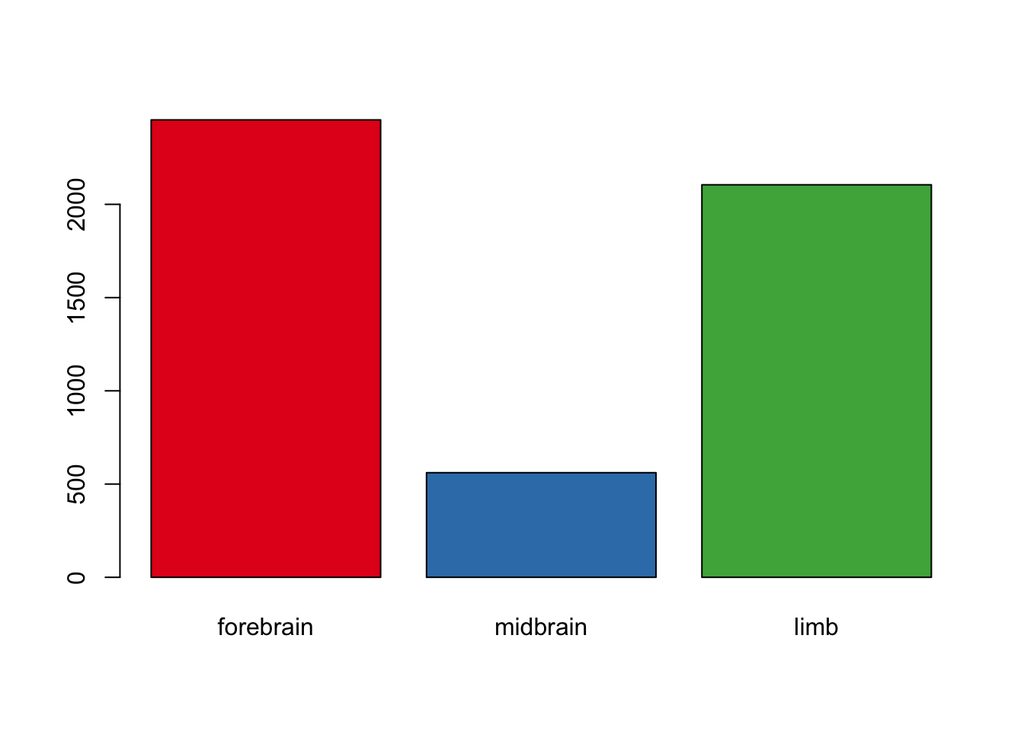

```r
# display this as a barplot
barplot(sapply(all.peaks,length),col=col)
```

### 12.2.2 - How large are these peaks?

```r
# statistics on the peak length for forebrain
summary(width(peaks.forebrain))
```

```
##    Min. 1st Qu.  Median    Mean 3rd Qu.    Max.
##   276.0   551.0   751.0   815.9  1001.0  2701.0
```

```r
# size distribution of the peaks
peaks.width = lapply(all.peaks,width)
lapply(peaks.width,summary)
```

```
## $forebrain
##    Min. 1st Qu.  Median    Mean 3rd Qu.    Max.
##   276.0   551.0   751.0   815.9  1001.0  2701.0
##
## $midbrain
##    Min. 1st Qu.  Median    Mean 3rd Qu.    Max.
##     276     526     676     717     876    2126
##
## $limb
##    Min. 1st Qu.  Median    Mean 3rd Qu.    Max.
##   276.0   476.0   601.0   682.6   826.0  2301.0
```

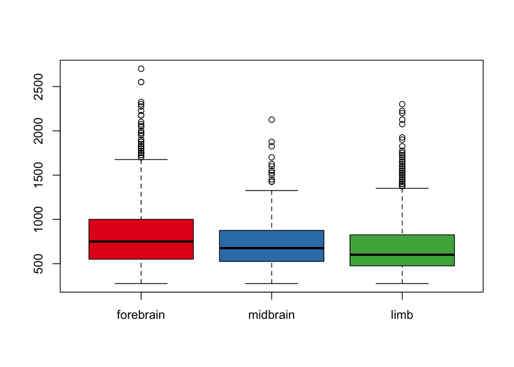

```r
# boxplot of the sizes
boxplot(peaks.width,col=col)
```

### 12.2.3 - What is the score of these peaks?

Can you adapt the previous code to display a boxplot of the peak score distribution for the Forebrain peak set (column `Maximum.Peak.Height`)?

### 12.2.4 - Where are the peaks located?

We can now display the genomic distribution of the peaks along the chromosomes, including the peak scores, using the `covplot` function from `ChIPSeeker`:

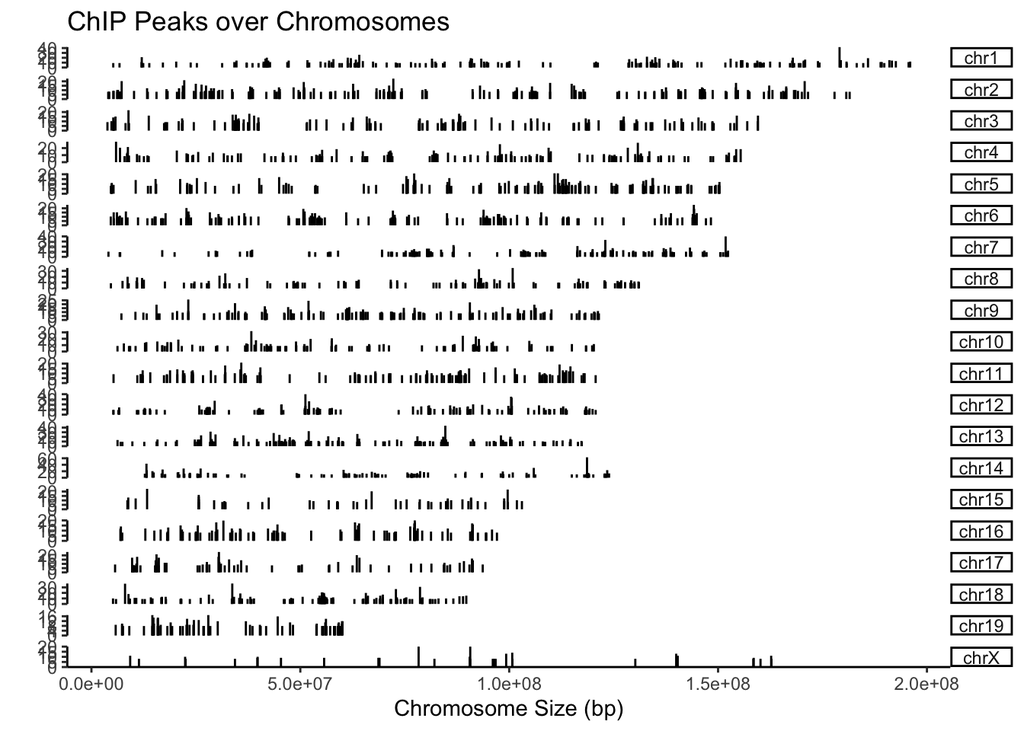

```r
# genome wide distribution
covplot(peaks.forebrain, weightCol="Maximum.Peak.Height")
```

**Exercice: use the option “lower” in covplot to display only the peaks with a score (Max.Peak.Height) above 10**

### 12.2.5 - How does the signal look like at TSS?

In addition to the genome wide plot, we can check if there is a tendency for the peaks to be located close to gene promoters.

```r
# define gene promoters
promoter = getPromoters(TxDb=txdb, upstream=5000, downstream=5000)

# compute the density of peaks within the promoter regions
tagMatrix = getTagMatrix(peaks.limb, windows=promoter)
```

```
## >> preparing start_site regions by gene... 2025-11-17 17:07:50
## >> preparing tag matrix...  2025-11-17 17:07:50
```

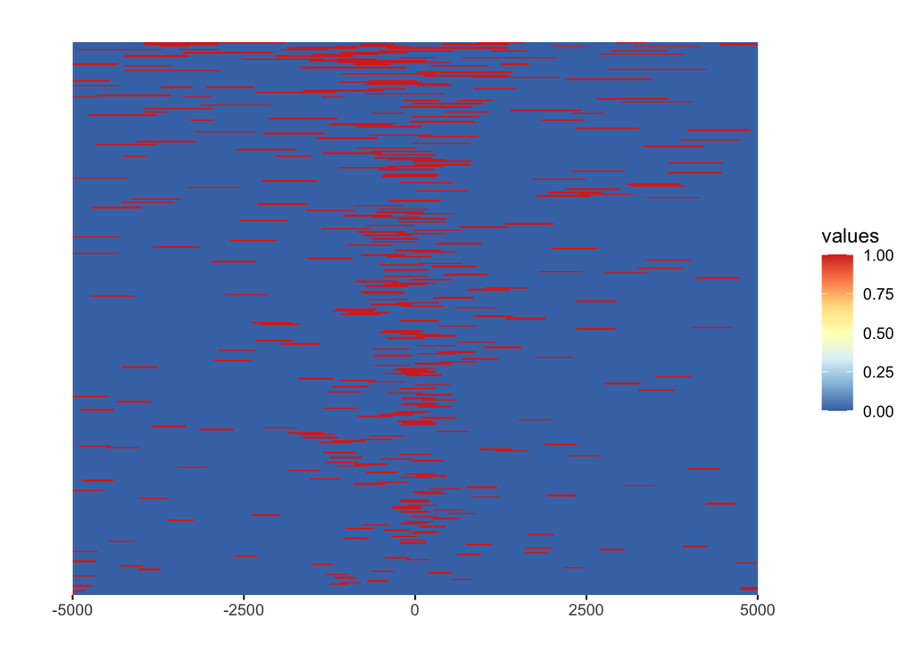

```r
# plot the density
tagHeatmap(tagMatrix, palette = "RdYlBu")
```

## 12.3 - Functional annotation of the peaks

We can now assign the peaks to the closest genes and genomic compartments (introns, exons, promoters, distal regions, etc…) This is done using the function `annotatePeak` which compares the peak files with the annotation file of the mouse genome. This function returns a complex object which contains all this information.

```r
peakAnno.forebrain = annotatePeak(peaks.forebrain, tssRegion=c(-3000, 3000), TxDb=txdb, annoDb="org.Mm.eg.db")
```

```
## >> preparing features information...      2025-11-17 17:08:50
## >> identifying nearest features...        2025-11-17 17:08:50
## >> calculating distance from peak to TSS...   2025-11-17 17:08:51
## >> assigning genomic annotation...        2025-11-17 17:08:51
## >> adding gene annotation...          2025-11-17 17:09:03
```

```
## >> assigning chromosome lengths           2025-11-17 17:09:04
## >> done...                    2025-11-17 17:09:04
```

```r
peakAnno.midbrain = annotatePeak(peaks.midbrain, tssRegion=c(-3000, 3000), TxDb=txdb, annoDb="org.Mm.eg.db")
```

```
## >> preparing features information...      2025-11-17 17:09:04
## >> identifying nearest features...        2025-11-17 17:09:04
## >> calculating distance from peak to TSS...   2025-11-17 17:09:04
## >> assigning genomic annotation...        2025-11-17 17:09:04
## >> adding gene annotation...          2025-11-17 17:09:05
```

```
## >> assigning chromosome lengths           2025-11-17 17:09:05
## >> done...                    2025-11-17 17:09:05
```

```r
peakAnno.limb = annotatePeak(peaks.limb, tssRegion=c(-3000, 3000), TxDb=txdb, annoDb="org.Mm.eg.db")
```

```
## >> preparing features information...      2025-11-17 17:09:05
## >> identifying nearest features...        2025-11-17 17:09:05
## >> calculating distance from peak to TSS...   2025-11-17 17:09:06
## >> assigning genomic annotation...        2025-11-17 17:09:06
## >> adding gene annotation...          2025-11-17 17:09:07
```

```
## >> assigning chromosome lengths           2025-11-17 17:09:07
## >> done...                    2025-11-17 17:09:07
```

### 12.3.1 - genomic localization

We can now analyze more in details the localization of the peaks (introns, exons, promoters, distal regions,…)

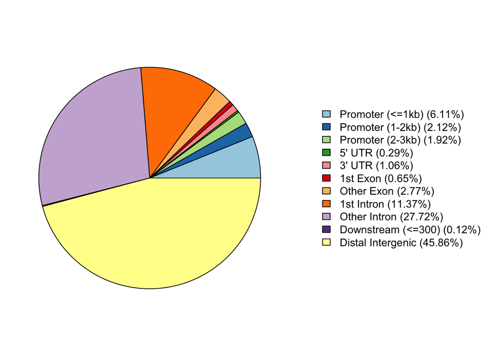

```r
# distribution of genomic compartments for forebrain peaks
plotAnnoPie(peakAnno.forebrain)
```

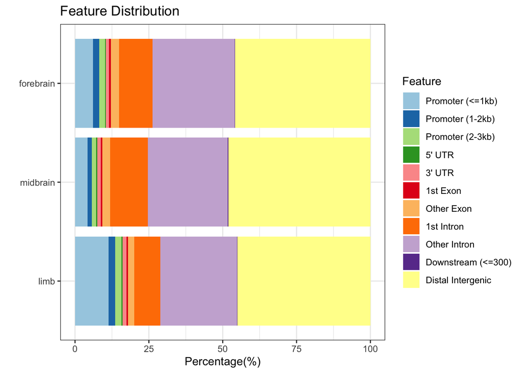

```r
# for all the peaks
plotAnnoBar(list(forebrain=peakAnno.forebrain, midbrain=peakAnno.midbrain,limb=peakAnno.limb))
```

**Question: do you see differences between the three peak sets?**

### 12.3.2 - functional annotation

An important step in ChIP-seq analysis is to interpret genes that are located close to the ChIP peaks. Hence, we need to 1. assign genes to peaks 2. compute functional enrichments of the target genes.

**Beware:** By doing so, we assume that the target gene of the peak is always the closest one. Hi-C/4C analysis have shown that in higher eukaryotes, this is not always the case. However, in the absence of data on the real target gene of ChIP-peaks, we can work with this approximation.

We will compute the enrichment of the Gene Ontology “Biological Process” categories in the set of putative target genes.

```r
# load the library
library(clusterProfiler)
```

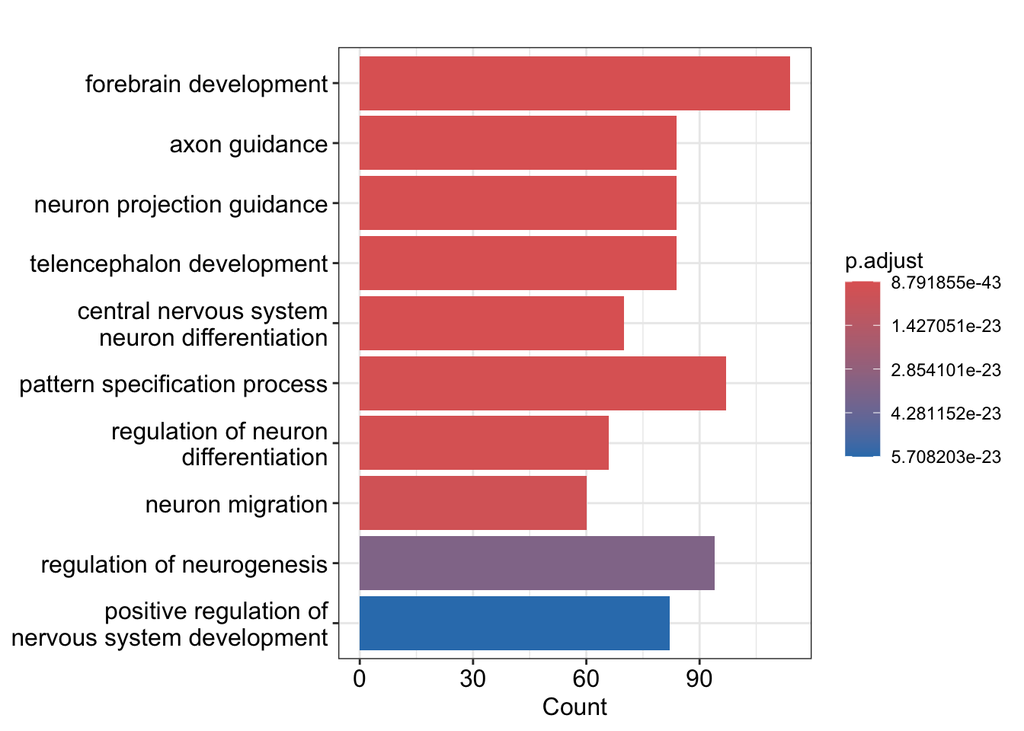

```r
# define the list of all mouse genes as a universe for the enrichment analysis
universe = mappedkeys(org.Mm.egACCNUM)

## extract the gene IDs of the forebrain target genes
genes.forebrain = peakAnno.forebrain@anno$geneId
ego.forebrain = enrichGO(gene          = genes.forebrain,
                universe      = universe,
                OrgDb         = org.Mm.eg.db,
                ont           = "BP",
                pAdjustMethod = "BH",
                pvalueCutoff  = 0.01,
                qvalueCutoff  = 0.05,
        readable      = TRUE)

# display the results as barplots
barplot(ego.forebrain,showCategory=10)
```

**Question: do you see an enrichment of the expected categories? What does the x-axis mean? What does the color mean?**

**Exercise:** redo this analysis for the limb dataset and check if the enriched categories make sense.

## 12.4 FAQ

### 12.4.1 How to download the data

**Goal**: Identify the datasets corresponding to the studied article and retrieve the data (reads as FASTQ files) corresponding to 2 replicates of a condition and the corresponding control.

#### 12.4.1.1 - Obtaining an identifier for a chosen dataset

NGS datasets are (usually) made freely accessible for other scientists, by depositing these datasets into specialized databanks. [Sequence Read Archive (SRA)](http://www.ncbi.nlm.nih.gov/sra) located in USA hosted by NCBI, and its European equivalent [European Nucleotide Archive (ENA)](http://www.ebi.ac.uk/ena) located in England hosted by EBI both contains **raw reads**.

Functional genomic datasets (transcriptomics, genome-wide binding such as ChIP-seq,…) are deposited in the databases [Gene Expression Omnibus (GEO)](http://www.ncbi.nlm.nih.gov/geo/) or its European equivalent [ArrayExpress](https://www.ebi.ac.uk/arrayexpress/).

Within an article of interest, search for a sentence mentioning the deposition of the data in a database. Here, the following sentence can be found at the end of the Materials and Methods section: *“All genome-wide data from this publication have been deposited in NCBI’s Gene Expression Omnibus (**GSE41195**).”* We will thus use the **GSE41195** identifier to retrieve the dataset from the **NCBI GEO** (Gene Expression Omnibus) database.

#### 12.4.1.2 - Accessing GSE41195 from GEO

1. The GEO database hosts processed data files and many details related to the experiments. SRA (Sequence Read Archive) stores the actual raw sequence data.
2. Search in Google **GSE41195**. Click on the first link to directly access the correct page on the GEO database.

[figure not shown]

3. This GEO entry is a mixture of expression analysis (Nimblegen Gene Expression Array), chip-chip and chip-seq. At the bottom of the page, click on the subseries related to the chip-seq datasets. (this subseries has its own identifier: **GSE41187**).

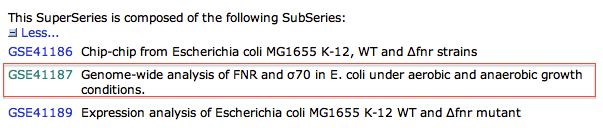

4. From this page, we will focus on the experiment **FNR IP ChIP-seq Anaerobic A**. At the bottom of the page, click on the link “**GSM1010219** - FNR IP ChIP-seq Anaerobic A”.
5. In the new page, go to the bottom to find the SRA identifier. This is the identifier of the raw dataset stored in the SRA database.

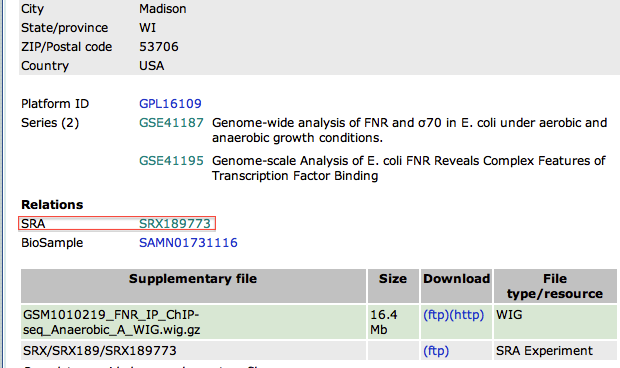

6. Copy the identifier **SRX189773** (do not click on the link that would take you to the SRA database, see below why)

#### 12.4.1.3 - Downloading FASTQ file from the ENA database

Although direct access to the SRA database at the NCBI is doable, SRA does not store sequences in a FASTQ format. So, in practice, it’s simpler (and quicker!!) to download datasets from the ENA database (European Nucleotide Archive) hosted by EBI (European Bioinformatics Institute) in UK. ENA encompasses the data from SRA.

1. Go to the [EBI](http://www.ebi.ac.uk/) website. Paste your SRA identifier (SRX189773) and click on the button “search”.

[figure not shown]

2. Click on the first result. On the next page, there is a link to the FASTQ file. For efficiency, this file has already been downloaded and is available in the “data” folder (FNR_IP_ChIP-seq_Anaerobic_A.fastq.gz)

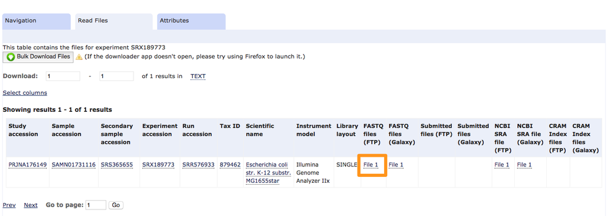

**tip**: To download the replicate and control datasets, we should redo the same steps starting from the GEO web page specific to the chip-seq datasets (see step 2.4) and choose **FNR IP ChIP-seq Anaerobic B** and **anaerobic INPUT DNA**. Downloaded FASTQ files are available in the data folder (FNR_IP_ChIP-seq_Anaerobic_B.fastq.gz and Anaerobic_INPUT_DNA.fastq.gz respectively)

**At this point, you have three FASTQ files, two IPs, one control (INPUT).**

### 12.4.2 How to extract peaks from the supplementary data of a publication ?

The processed peaks (BED file) is sometimes available on the GEO website, or in supplementary data. Unfortunately, most of the time, the peak coordinates are embedded into supplementary tables and thus not usable “as is”. This is the case for the studied article. To be able to use these peaks (visualize them in a genome browser, compare them with the peaks found with another program, perform downstream analyses…), you will need to (re)-create a BED file from the information available. Here, Table S5 provides the coordinates of the summit of the peaks. The coordinates are for the same assembly as we used.

1. copy/paste the first column into a new file, and save it as retained_peaks.txt
2. use a PERL command (or awk if you know this language) to create a BED-formatted file. As we need start and end coordinates, we will arbitrarily take +/-50bp around the summit.

```bash
perl -lane 'print "gi|49175990|ref|NC_000913.2|\t".($F[0]-50)."\t".($F[0]+50)."\t" ' retained_peaks.txt > retained_peaks.bed
```

3. The BED file looks like this: > gi|49175990|ref|NC_000913.2| 120 220 > gi|49175990|ref|NC_000913.2| 20536 20636 > gi|49175990|ref|NC_000913.2| 29565 29665 > gi|49175990|ref|NC_000913.2| 34015 34115
4. Depending on the available information, the command will be different.

### 12.4.3 - How to obtain the annotation (=Gene) GTF file for IGV?

Annotation files can be found on genome websites, NCBI FTP server, Ensembl, … However, IGV required GFF format, or BED format, which are often not directly available. Here, I downloaded the annotation from the [UCSC Table browser](http://microbes.ucsc.edu/cgi-bin/hgTables?org=Escherichia+coli+K12&db=eschColi_K12&hgsid=1465191&hgta_doMainPage=1) as “Escherichia_coli_K_12_MG1655.annotation.gtf”. Then, I changed the “chr” to the name of our genome with the following PERL command:

```bash
perl -pe 's/^chr/gi\|49175990\|ref\|NC_000913.2\|/' Escherichia_coli_K_12_MG1655.annotation.gtf > Escherichia_coli_K_12_MG1655.annotation.fixed.gtf
```

This file will work directly in IGV

# References

Heinz, Sven, Christopher Benner, Nathanael Spann, Eric Bertolino, Yin C. Lin, Peter Laslo, Jason X. Cheng, Cornelis Murre, Harinder Singh, and Christopher K. Glass. 2010. “Simple Combinations of Lineage-Determining Transcription Factors Prime Cis-Regulatory Elements Required for Macrophage and b Cell Identities.” *Molecular Cell* 38 (4): 576–89. https://doi.org/10.1016/j.molcel.2010.05.004.

Langmead, Ben, and Steven L Salzberg. 2012. “Fast Gapped-Read Alignment with Bowtie 2.” *Nature Methods* 9 (4): 357–59. https://doi.org/10.1038/nmeth.1923.

Langmead, Ben, Cole Trapnell, Mihai Pop, and Steven L. Salzberg. 2009. “Ultrafast and Memory-Efficient Alignment of Short DNA Sequences to the Human Genome.” *Genome Biology* 10 (3): R25. https://doi.org/10.1186/gb-2009-10-3-r25.

Li, Heng, Bob Handsaker, Alec Wysoker, Tim Fennell, Jue Ruan, Nils Homer, Gabor Marth, Goncalo Abecasis, and Richard Durbin. 2009. “The Sequence Alignment/Map Format and SAMtools.” *Bioinformatics* 25 (16): 2078–79. https://doi.org/10.1093/bioinformatics/btp352.

“Picard Tools - By Broad Institute.” n.d. Accessed August 26, 2016. http://broadinstitute.github.io/picard/.

Quinlan, Aaron R, and Ira M Hall. 2010. “BEDTools: A Flexible Suite of Utilities for Comparing Genomic Features.” *Bioinformatics* 26 (6): 841–42. https://doi.org/10.1093/bioinformatics/btq033.

Ramírez, Fidel, Devon P. Ryan, Björn Grüning, Vivek Bhardwaj, Fabian Kilpert, Andreas S. Richter, Steffen Heyne, Friederike Dündar, and Thomas Manke. 2016. “deepTools2: A Next Generation Web Server for Deep-Sequencing Data Analysis.” *Nucleic Acids Research* 44 (W1): W160–65. https://doi.org/10.1093/nar/gkw257.

Yu, Guangchuang, Li-Gen Wang, Yanyan Han, and Qing-Yu He. 2012. “clusterProfiler: An r Package for Comparing Biological Themes Among Gene Clusters.” *OMICS: A Journal of Integrative Biology* 16 (5): 284–87. https://doi.org/10.1089/omi.2011.0118.

Yu, Guangchuang, Li-Gen Wang, and Qing-Yu He. 2015. “ChIPseeker: An r/Bioconductor Package for ChIP Peak Annotation, Comparison and Visualization.” *Bioinformatics* 31 (14): 2382–83. https://doi.org/10.1093/bioinformatics/btv145.